# Tarea 9: Tragamonedas

Alejandra Lelo de Larrea Ibarra

10/05/2019

# Algoritmo miope

Simula una corrida del tragamonedas usando el algoritmo e-miope, con $\epsilon = 0.2$ y número de corridas $n = 500$. Al final de la corrida, ¿cuántas veces jalaste cada palanca? ¿Cuál es la recompensa total durante el experimento?

Usa el siguiente código copiado de la clase:

## Funciones para algoritmo miope

```r
# Carga paquetes
library(tidyverse)
library(DT)

# Función para maquina poisson
crear_maquina_poisson <- function(lambda){

  # utilizamos recompensas poisson con distintas medias lambda

  # No de palancas
  n_brazos <- length(lambda)

  # una corrida para para el brazo j
  simular_maquina <- function(brazo){
    rpois(1, lambda = lambda[brazo])
  }

  # Devuelve el resultado
  simular_maquina
}
```

```r
# Posibles valores de lambda (tasa)
lambda <- c(8, 9, 7, 5, 2)

# Función para crear la maquina poisson con los valores lambda específicos
sim <- crear_maquina_poisson(lambda = lambda)
```

```r
# Función para el algoritmo epsilon miope
crear_epsilon_miope <- function(epsilon, inicial = 1, sim_fun){

  # Extrae numero de brazos
  n_brazos <- environment(sim_fun)$n_brazos

  # inicializa el conteo de c/brazo
  conteos <- rep(0, n_brazos)

  # Inicializa las iteraciones
  iteracion <- 0

  #recompensas <- vector("list", n_brazos)

  # Inicializa el valor total de las recomensas para c/brazo
  sumas <- rep(0, n_brazos)

  # Inicializa
  S <- rep(0, n_brazos)

  # El mejor brazo comiezna en el 1 por default o el valor
  # asignado al argumento 'inicial'.
  mejor <- inicial

  # Epsilon fijado para seleccionar un brazo aleatorio.
  epsilon <- epsilon

  # Función central
  fun <- function(){

    # Con probabilidad epsilon...
    if(runif(1) <= epsilon){

      #explorar (selecciona un nuevo brazo)
      brazo <- sample.int(n_brazos, 1)

      # con probabilidad 1-epsilon ...
    } else {

      # explotar (selecciona el mejor brazo al momento)
      brazo <- mejor
    }

    # Corre la máquina (poisson, bernoulli, etc...) para simular una recompensa.
    sim <- sim_fun(brazo)

    #recompensas[[brazo]] <<- c(recompensas[[brazo]], sim)

    # Calcula la media anterior
    media_ant <- ifelse(conteos[brazo] > 0, sumas[brazo] / conteos[brazo], 0)

    # Actualiza el conteo del brazo que se utilizó.
    conteos[brazo] <<- conteos[brazo] + 1

    # Actualiza al suma del brazo con el valor simulado.
    sumas[brazo] <<- sumas[brazo] + sim

    # Calcula la nueva media del brazo
    media <- sumas[brazo] / conteos[brazo]

    # Calcula la desviación estándar (dinámica)
    S[brazo] <<- S[brazo] + (sim - media_ant)*(sim - media)

    # Extrae el brazo con la mejor media hasta el momento.
    mejor <<- which.max(sumas /conteos)

    # Actualiza el contador de las iteraciones
    iteracion <<- iteracion + 1

    # Actualiza la inforamción a devolver.
    # En cada iteración devuelve un df con el status de cada brazo.
    estado <- data_frame(n = iteracion,
                         brazo = 1:n_brazos,
                         conteo = conteos,
                         suma = sumas,
                         media = sumas / conteos,
                         ee = sqrt(S / conteos)/sqrt(conteos))
    # Devuelve el estado
    return(estado)
  }

  # Devuelve la función
  fun
}
```

## Simulaciones

```r
# Creamos la funcíon para el algoritmo miope con un epsilon de 0.2, que inicie en 4 y con la máquina poisson anterior como función de simulación.
e_miope<-crear_epsilon_miope(epsilon = 0.2,inicial = 5,sim_fun = sim )

# Corremos 500 simulaciones del algoritmo
set.seed(124433)
iter<-lapply(1:500,function(x)e_miope()) %>%  # simula 500 iter del algoritmo miope
  bind_rows %>% # junta data frames
  as_tibble() %>%   # convierte a tibble
  arrange(n)

# Vemos el dataframe
DT::datatable(iter)
```

|  | n | brazo | conteo | suma | media | ee |
| --- | --- | --- | --- | --- | --- | --- |
| 1 | 1 | 1 | 0 | 0 |  |  |
| 2 | 1 | 2 | 0 | 0 |  |  |
| 3 | 1 | 3 | 0 | 0 |  |  |
| 4 | 1 | 4 | 0 | 0 |  |  |
| 5 | 1 | 5 | 1 | 2 | 2 | 0 |
| 6 | 2 | 1 | 1 | 11 | 11 | 0 |
| 7 | 2 | 2 | 0 | 0 |  |  |
| 8 | 2 | 3 | 0 | 0 |  |  |
| 9 | 2 | 4 | 0 | 0 |  |  |
| 10 | 2 | 5 | 1 | 2 | 2 | 0 |

[output cut: 2490 more lines]

## Resultados

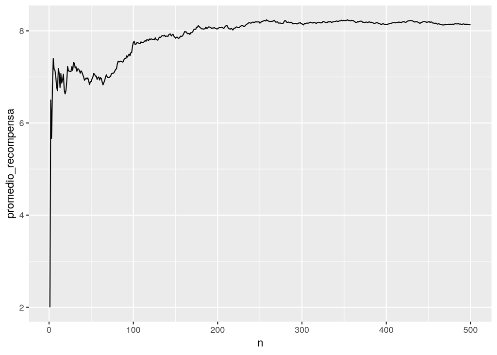

```r
# Obtenemos un resumen de la simulación

# Recompensa promedio en cada iteración
resumen<-iter %>%
  group_by(n) %>%
  summarise(promedio_recompensa = sum(suma)/sum(conteo))

# Grafica de la recompensa promedio en cda iteración
ggplot(resumen, aes(x=n,y=promedio_recompensa)) + geom_line()
```

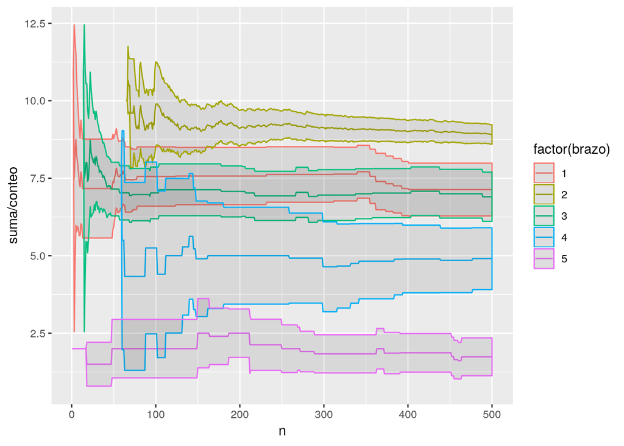

```r
# Monitoreo de los brazos en el "tiempo"
ggplot(iter,aes(x=n,
                y = suma/conteo,group = brazo,
                ymin = suma/conteo - 2*ee,
                ymax = suma/conteo + 2*ee,
                colour = factor(brazo))) +
  geom_line() +
  geom_ribbon(alpha = 0.1)
```

El promedio de cada uno de los brazos converge rápidamente al valor de la lambda que utliza cada uno. Los brazos 1 y se traslapan demasiado, los brazos 4 y 5 no se traslapan (al final) pero son los peores. El mejor brazo (2) está bien diferenciado del resto desde la iteración 250 aproximadamente.

```r
# Número de veces que se corrió cada brazo
filter(iter,n==500)%>%mutate(lambda=lambda)%>%select(n,brazo,lambda,everything())
```

```
## # A tibble: 5 x 7
##       n brazo lambda conteo  suma media    ee
##   <dbl> <int>  <dbl>  <dbl> <dbl> <dbl> <dbl>
## 1   500     1      8     37   264  7.14 0.426
## 2   500     2      9    372  3315  8.91 0.156
## 3   500     3      7     51   352  6.90 0.397
## 4   500     4      5     21   103  4.90 0.499
## 5   500     5      2     19    33  1.74 0.305
```

Se puede ver que el brazo que más se utilizó fue el no. 2 que corresponde a la tasa más alta de recompensa.

```r
# Recompensa total.
filter(iter,n==500)%>%select(suma)%>%sum()
```

```
## [1] 4067
```

# Tragamonedas bayesiano

Ahora utiliza un tragamonedas bayesiano para repetir este experimento. Tips:

- Uitliza como iniciales distribuciones exponenciales (que son gamma) con media 5 ($\lambda = 1/5)$. Por ejemplo, esto coincide con el escenario de que en un porcentaje alto de los casos el retorno promedio que esperamos es menor a 10 unidades, y que en más de la mitad de los casos el retorno es 3-4 unidades.
- Utiliza el hecho de que si la inicial es exponencial con parámetro $\lambda$, las observaciones tienen distribución poisson, y observamos una suma de retornos igual a $S$ en $n$ pruebas, entonces la posterior tiene distribución gamma con parámetros $\alpha = S + 1$ y $\beta= \lambda + n$. La puedes simular, por ejemplo, haciendo:

```r
n <- 10 # 10 pruebas
suma <- 23 # suma de observaciones (retornos)
media <- 23/10
lambda_1 <- 1/5
media
```

```
## [1] 2.3
```

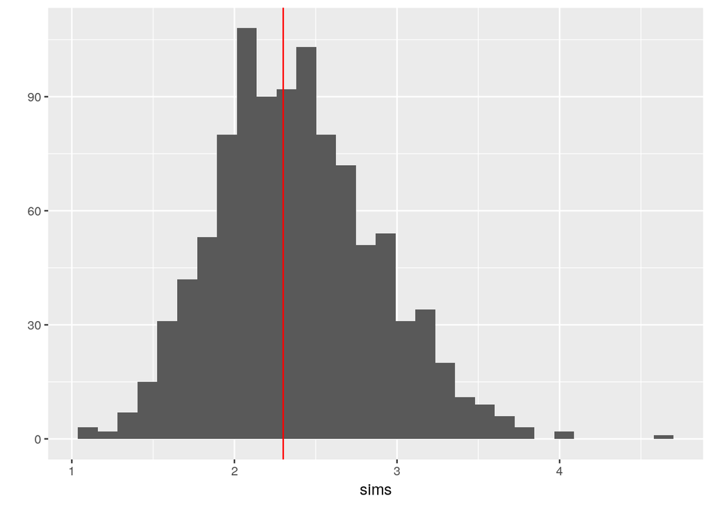

```r
# posterior
sims <- rgamma(1000, suma + 1, n + lambda_1)
qplot(sims) +
  geom_vline(xintercept = media, colour = "red")
```

- Usa el ejemplo que vimos en clase y sustituye las distribuciones correctas. Solo tienes que cambiar tres líneas del código que usamos para el caso bernoulli (donde aparece rbeta).

```r
# Crear función de bayesiana
crear_bayesiano <- function(sim_fun, lambda_1=1/5, num_sims = 1000){

  # Extrae el número de brazos.
  n_brazos <- environment(sim_fun)$n_brazos

  # Inicializa el contador para el conteo de c/brazo
  conteos <- rep(0, n_brazos)

  # Inicializa el contador para la suma de c/brazo
  sumas <- rep(0, n_brazos)

  # Inicializa el contador de iteraciones
  iteracion <- 0

  # Función central
  fun <- function(){

    # Simulaciones de la posterior
    sims_post <- tibble(brazos = 1:n_brazos,
                        conteos = conteos,
                        sumas = sumas) %>% # crea un data frame con info de c/brazo
      mutate(sims = map2(conteos, sumas, function(n, y){
        tibble(sim_no = 1:num_sims,
               valor = rbeta(num_sims, y + 1, lambda_1+ n)) })) %>% # Simula la posterior de las probabilidades como una beta.
      select(brazos, sims) %>% # selecciona la variable brazos y los datos de las simulaicones.
      unnest %>% # desagrega
      group_by(sim_no) %>% # agrupa por no de simulación
      filter(valor == max(valor)) # extrae el de mayor probabilidad posterior.


    # Dataframe de pesos finales
    pesos <- tibble(brazos = 1:n_brazos)

    # Crea un rsumen de las simulaciones posteriores
    resumen <- sims_post %>%  # simulaciones postriores
      ungroup() %>% # desagrupa
      select(brazos) %>% # selecciona los brazos
      group_by(brazos) %>% # agrupa por brazo
      summarise(prop = n() / num_sims) # calcula la prop en que apareció cada brazo.

    # Completa el data frame de pesos
    pesos <- pesos %>% # toma los brazos
      left_join(resumen, by = "brazos") %>% # agrega el resumen de cada brazo
      mutate(prop = ifelse(is.na(prop), 0, prop)) # asigna 0 a los que no tienen proporción.

    # Muestrea un brazo usando las proporciones como probabilidades
    brazo <- sample(pesos$brazos, 1, prob = pesos$prop)

    # Corre la maquina seleccionada en el brazo muestreado
    sim <- sim_fun(brazo)

    # Actualiza las iteracioens
    iteracion <<- iteracion + 1

    # Atualiza el conteo del brazo
    conteos[brazo] <<- conteos[brazo] + 1

    # Actualiza la recompensa del brazo con el valor simulado
    sumas[brazo] <<- sumas[brazo] + sim

    # Genera un dataframe con el estado de la iteración
    estado <- data_frame(n = iteracion,
                         brazo = 1:n_brazos,
                         conteo = conteos,
                         suma = sumas) %>% # Info de los brazos.
      mutate(inf = map2_dbl( conteo, suma, function(n, y){ qbeta(0.05, y + 1, lambda_1+ n)
      })) %>% # calcula el cuantil 0.05 de la posterior
      mutate(sup = map2_dbl(suma, conteo, function(n, y){
        qbeta(0.95, y + 1, lambda_1+ n) })) # calcula el cuantil 0.95 de la posterior

    # Devuelve el estado
    estado
  }

  # Devuelve la función
  fun
}
```

## Simulaciones

```r
set.seed(124433)

# Función bayessiano con la maquina bernoulli
bayesiano <- crear_bayesiano(sim_fun = sim)

# Extrae las 500 simulaciones
iter_bayes <- lapply(1:500, function(i){
bayesiano()
}) %>% bind_rows %>% as_tibble()

# Vemos el dataframe
DT::datatable(iter_bayes)
```

|  | n | brazo | conteo | suma | inf | sup |
| --- | --- | --- | --- | --- | --- | --- |
| 1 | 1 | 1 | 0 | 0 | 0.2262190625 | 0.9999996875 |
| 2 | 1 | 2 | 0 | 0 | 0.2262190625 | 0.9999996875 |
| 3 | 1 | 3 | 0 | 0 | 0.2262190625 | 0.9999996875 |
| 4 | 1 | 4 | 1 | 1 | 0.197412931680857 | 0.956432723791155 |
| 5 | 1 | 5 | 0 | 0 | 0.2262190625 | 0.9999996875 |
| 6 | 2 | 1 | 0 | 0 | 0.2262190625 | 0.9999996875 |
| 7 | 2 | 2 | 0 | 0 | 0.2262190625 | 0.9999996875 |
| 8 | 2 | 3 | 1 | 10 | 0.737891910119018 | 0.358922069963139 |
| 9 | 2 | 4 | 1 | 1 | 0.197412931680857 | 0.956432723791155 |
| 10 | 2 | 5 | 0 | 0 | 0.2262190625 | 0.9999996875 |

[output cut: 2490 more lines]

## Resultados

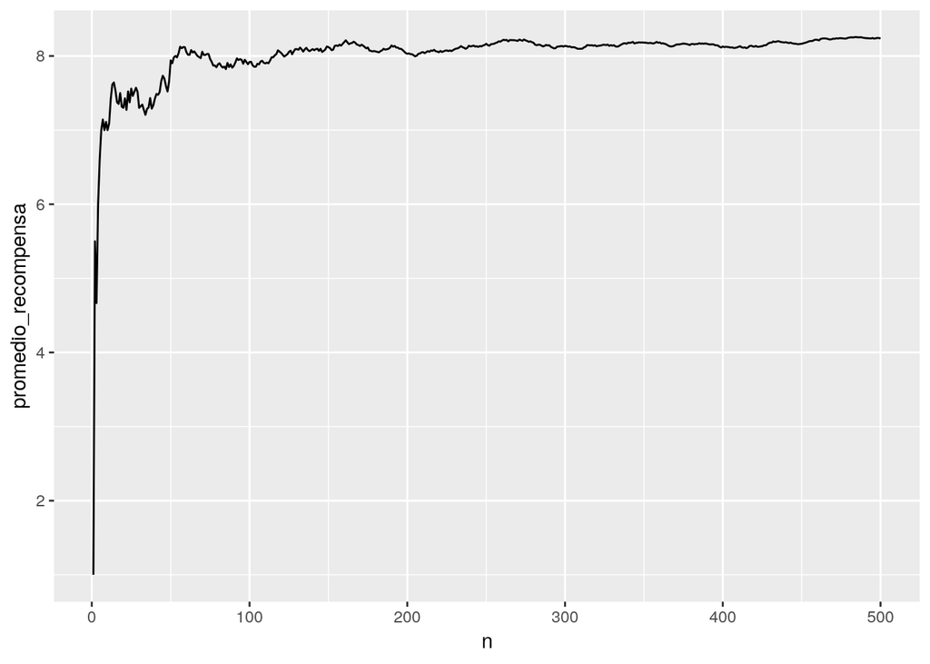

```r
# Obtenemos un resumen de la simulación

# Recompensa promedio en cada iteración
resumen<-iter_bayes %>%
  group_by(n) %>%
  summarise(promedio_recompensa = sum(suma)/sum(conteo))

# Grafica de la recompensa promedio en cda iteración
ggplot(resumen, aes(x=n,y=promedio_recompensa)) + geom_line()
```

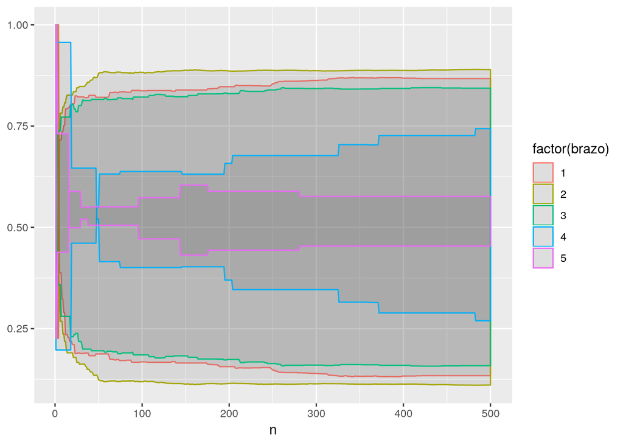

```r
# Monitoreo de los brazos en el "tiempo"
ggplot(iter_bayes,aes(x=n,
                ymin = inf,
                ymax = sup,
                group = brazo,
                colour = factor(brazo))) +
  geom_ribbon(alpha = 0.1)
```

```r
# Número de veces que se corrió cada brazo
filter(iter_bayes,n==500)%>%mutate(lambda=lambda)%>%select(n,brazo,lambda,everything())
```

```
## # A tibble: 5 x 7
##       n brazo lambda conteo  suma   inf   sup
##   <dbl> <int>  <dbl>  <dbl> <dbl> <dbl> <dbl>
## 1   500     1      8     88   687 0.867 0.134
## 2   500     2      9    339  2996 0.890 0.111
## 3   500     3      7     53   359 0.843 0.159
## 4   500     4      5     12    56 0.744 0.269
## 5   500     5      2      8    20 0.576 0.454
```

Se puede que el brazo que más se utilizó fue el no. 2 que corresponde a la tasa más alta de recompensa y el que menos se utilizó fue el brazo número 5 que es el que tiene la lambda más chica.

```r
# Recompensa total.
filter(iter_bayes,n==500)%>%select(suma)%>%sum()
```

```
## [1] 4118
```